# Class 8

Serina Huang

October 25, 2018

## K-means clustering

Our first example with `kmeans()` function.

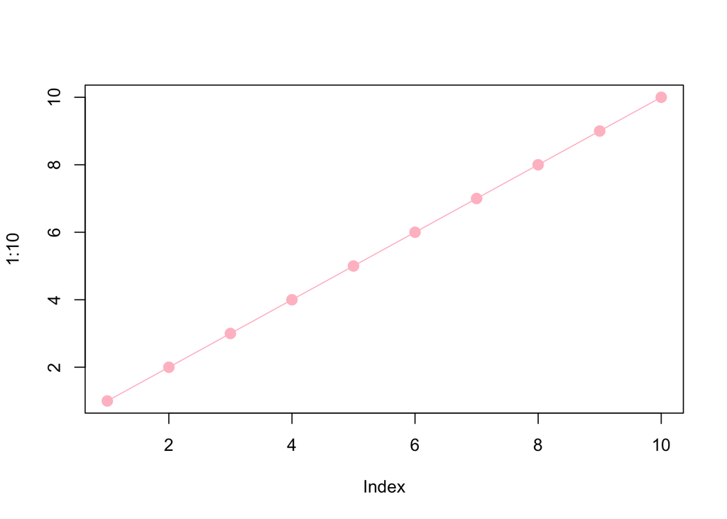

```r
# Example plot to see how Rmarkdown works
plot(1:10, typ="o", cex=2, pch = 20, col="pink")
```

Back to k-means…

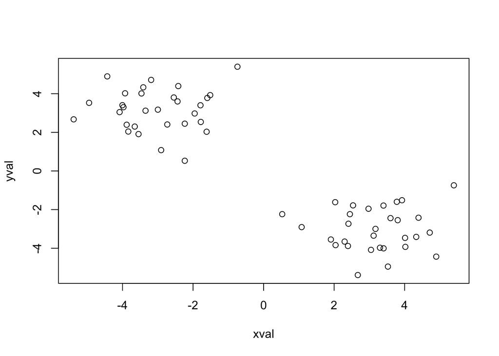

```r
# Generate some example data for clustering
tmp <- c(rnorm(30,-3), rnorm(30,3))
example <- cbind(xval = tmp, yval = rev(tmp))
plot(example)
```

Use the kmeans() function and print the results.

```r
k2 <- kmeans(example, centers = 2, nstart = 20)
k2
```

```
## K-means clustering with 2 clusters of sizes 30, 30
##
## Cluster means:
##        xval      yval
## 1 -3.019584  3.171946
## 2  3.171946 -3.019584
##
## Clustering vector:
##  [1] 1 1 1 1 1 1 1 1 1 1 1 1 1 1 1 1 1 1 1 1 1 1 1 1 1 1 1 1 1 1 2 2 2 2 2
## [36] 2 2 2 2 2 2 2 2 2 2 2 2 2 2 2 2 2 2 2 2 2 2 2 2 2
##
## Within cluster sum of squares by cluster:
## [1] 70.6665 70.6665
##  (between_SS / total_SS =  89.1 %)
##
## Available components:
##
## [1] "cluster"      "centers"      "totss"        "withinss"
## [5] "tot.withinss" "betweenss"    "size"         "iter"
## [9] "ifault"
```

Q. How many points are in each cluster?

```r
k2$size
```

```
## [1] 30 30
```

Q. What ‘component’ of your result object details cluster assignment/membership?

```r
k2$cluster
```

```
##  [1] 1 1 1 1 1 1 1 1 1 1 1 1 1 1 1 1 1 1 1 1 1 1 1 1 1 1 1 1 1 1 2 2 2 2 2
## [36] 2 2 2 2 2 2 2 2 2 2 2 2 2 2 2 2 2 2 2 2 2 2 2 2 2
```

```r
table(k2$cluster)
```

```
##
##  1  2
## 30 30
```

Q. What is the cluster center?

```r
k2$centers
```

```
##        xval      yval
## 1 -3.019584  3.171946
## 2  3.171946 -3.019584
```

Plot the example colored by the cluster assignment. Label cluster centers as blue points.

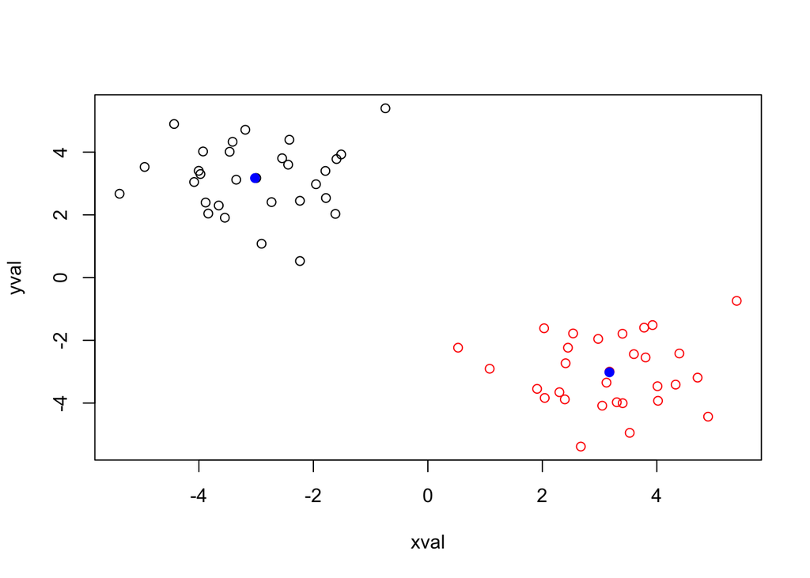

```r
plot(example, col = k2$cluster)
points(k2$centers, col = "blue", pch = 20, cex = 1.5)
```

```r
# palette(c("blue", "red"))
```

Q. Repeat for k = 3, which has the lower tot.withinss?

```r
k3 <- kmeans(example, centers = 3, nstart = 20)
k3$tot.withinss
```

```
## [1] 115.3421
```

```r
k2$tot.withinss
```

```
## [1] 141.333
```

k = 3 has a lower tot.withinss. A lower tot.withinss doesn’t necessarily mean it’s better clustering. In fact, to tell what is the best k, you should make a scree plot.

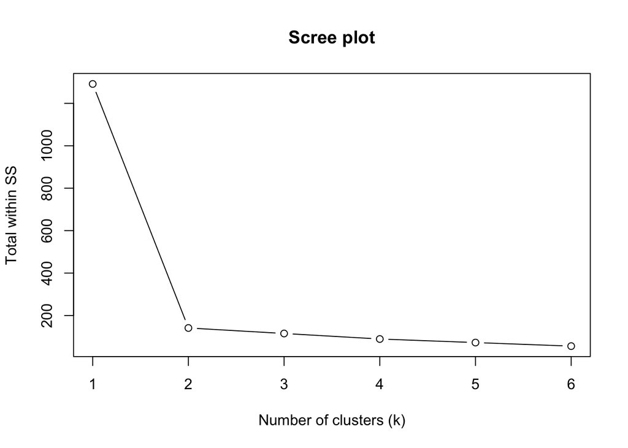

```r
k1 <- kmeans(example, centers = 1, nstart = 20)
k4 <- kmeans(example, centers = 4, nstart = 20)
k5 <- kmeans(example, centers = 5, nstart = 20)
k6 <- kmeans(example, centers = 6, nstart = 20)

ss <- c(k1$tot.withinss, k2$tot.withinss, k3$tot.withinss, k4$tot.withinss, k5$tot.withinss, k6$tot.withinss)
plot(ss, typ = "b", xlab = "Number of clusters (k)", ylab = "Total within SS", main = "Scree plot")
```

From the scree plot, we can see that the “elbow” falls at 2 clusters, meaning 2 is the optimal number of clusters for our dataset.

## Hierarchical clustering

First, create a distance matrix by calculating the Euclidean distance between all the points. This will tell you how similar each point is to another point.

```r
dist_matrix <- dist(example)
```

The hclust() function returns a hierarchical clustering model. Let’s see what the output is.

```r
hc <- hclust(dist_matrix)
hc
```

```
##
## Call:
## hclust(d = dist_matrix)
##
## Cluster method   : complete
## Distance         : euclidean
## Number of objects: 60
```

The output isn’t too useful, so let’s see if we can extract more information about the distance matrix.

```r
# What is the dimension of the distance matrix?
dim(dist_matrix)
```

[output not shown]

```r
# Turn dist_matrix into a matrix by filling in the blanks
head( as.matrix(dist_matrix), n = 2L )
```

```
##          1        2        3         4         5        6        7
## 1 0.000000 1.644254 2.218664 1.4759722 0.4977176 2.457403 1.919626
## 2 1.644254 0.000000 1.939828 0.1685461 1.9464592 1.850633 3.473011
##          8         9       10       11       12       13       14       15
## 1 1.169652 0.7469117 1.936530 3.290319 1.523556 1.391207 1.652439 3.304864
## 2 0.981834 1.8975173 2.537598 3.076252 3.167809 1.039060 2.990764 1.660981
##         16        17       18       19       20       21       22       23
## 1 2.310373 0.5978924 1.426560 2.919980 1.300491 1.418117 1.053064 3.159010
## 2 2.415102 1.0469295 2.688124 3.457466 2.002664 2.863448 1.663157 4.069725
##         24        25       26       27       28       29       30       31
## 1 1.942849 0.4632616 1.954972 1.051398 1.648469 1.988644 2.010084 8.567987
## 2 2.715442 1.4137187 1.019254 0.593260 2.821178 1.950725 2.543447 9.330159
##         32       33       34       35       36       37        38       39
## 1 8.600175 7.841566 7.050851 8.223993 6.375921 8.399402  9.243935 7.675304
## 2 9.226570 8.731072 7.537775 8.669801 6.998043 9.216414 10.209435 8.361237
##         40       41       42       43       44       45       46       47
## 1 7.287167 7.891372  9.37546 7.601281 6.821373 8.931741 8.270597 7.601468
## 2 8.218845 8.624704 10.20572 8.484148 7.398182 9.607439 8.338497 8.537847
##         48       49        50       51       52       53       54       55
## 1 7.836184 6.296460  9.909661 8.478150 5.891219 7.611300 5.437060 8.946638
## 2 8.376311 7.306995 10.533831 9.250971 6.577906 8.165207 6.490076 9.454632
##         56       57       58       59       60
## 1 6.954365 7.246477 8.798654 7.324637 6.622514
## 2 7.725375 7.648335 9.379471 7.692959 7.324637
```

```r
# Compare the dimension of the original example dataset vs. dimension of new distance matrix
dim(example)
```

```
## [1] 60  2
```

```r
dim( as.matrix(dist_matrix) )
```

```
## [1] 60 60
```

Now we know what’s in the distance matrix, we can plot the hierarchical clustering model as a dendrogram.

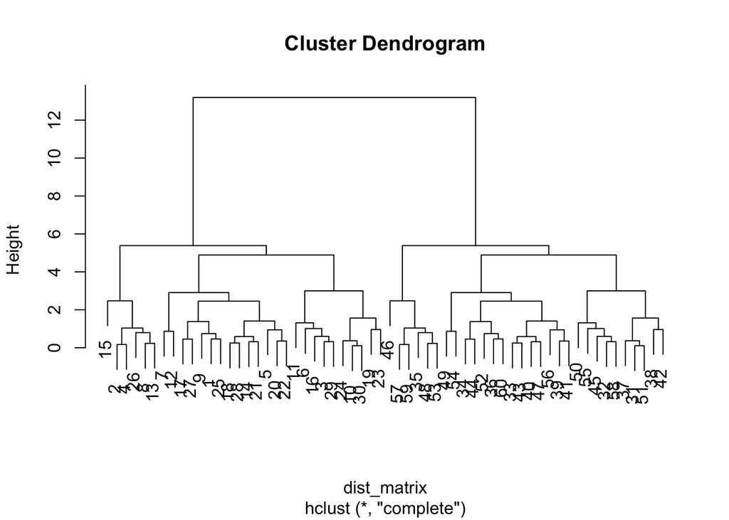

```r
plot(hc)
```

This makes sense. Our original example vector consists of 30 points centered around -3, and the next 30 points centered around 3. Note: the number labels on the x-axis is not the value of the point, but the index.

We see that at height around 5.5, 2 clusters emerge. We can draw a straight line on the plot to show this.

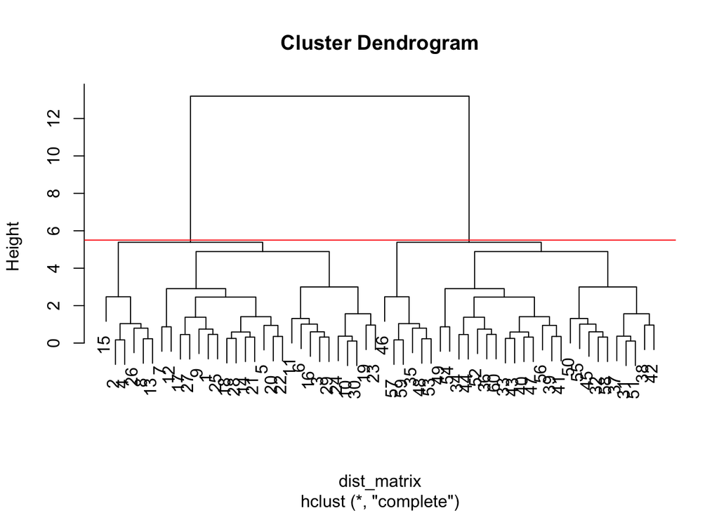

```r
plot(hc)
abline(h = 5.5, col = "red")
```

That’s useful. However, if you can’t tell where the height is visually, or if you want to know the height at which 10 clusters emerge, you will need the cutree function.

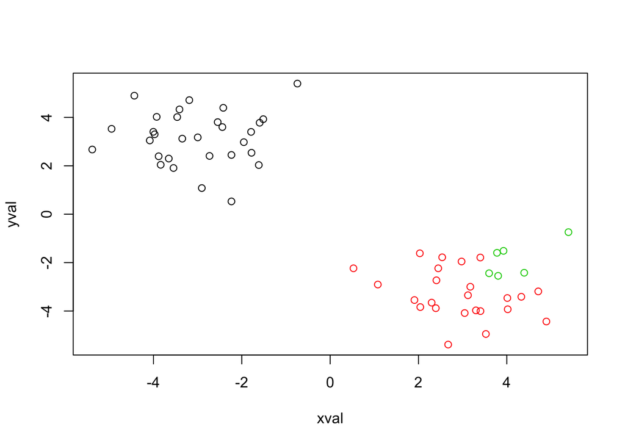

```r
# Where should I cut to get 3 clusters (groups)?
three_groups <- cutree(hc, k = 3)
# Visualize the clusters made by hierarchical clustering and cutree
plot(example, col = three_groups)
```

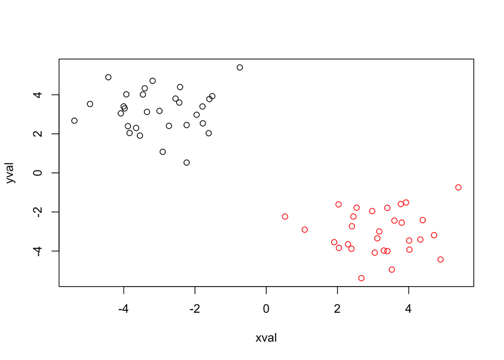

```r
# Where should I cut to get a height of 8?
two_groups <- cutree(hc, h = 8)
# Visualize this too. We should see 2 clusters
plot(example, col = two_groups)
```

Note: the output of cutree yields a vector indicating membership.

Now let’s try different hierarchical clustering methods.

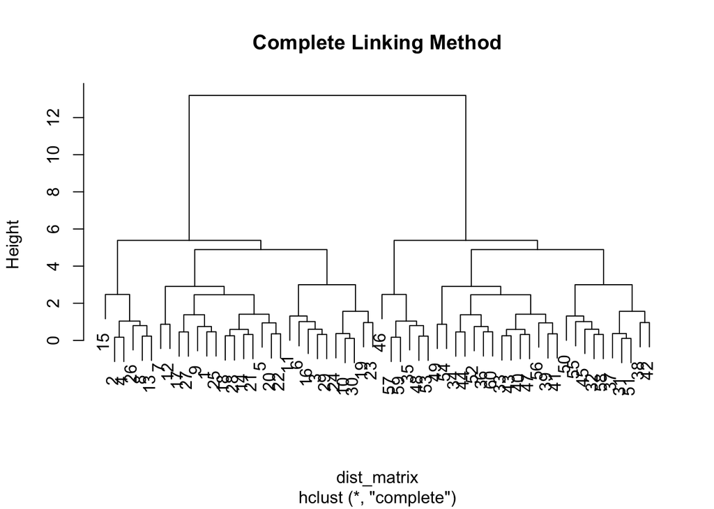

```r
hc.complete <- hclust(dist_matrix, method = "complete")
plot(hc.complete, main= "Complete Linking Method")
```

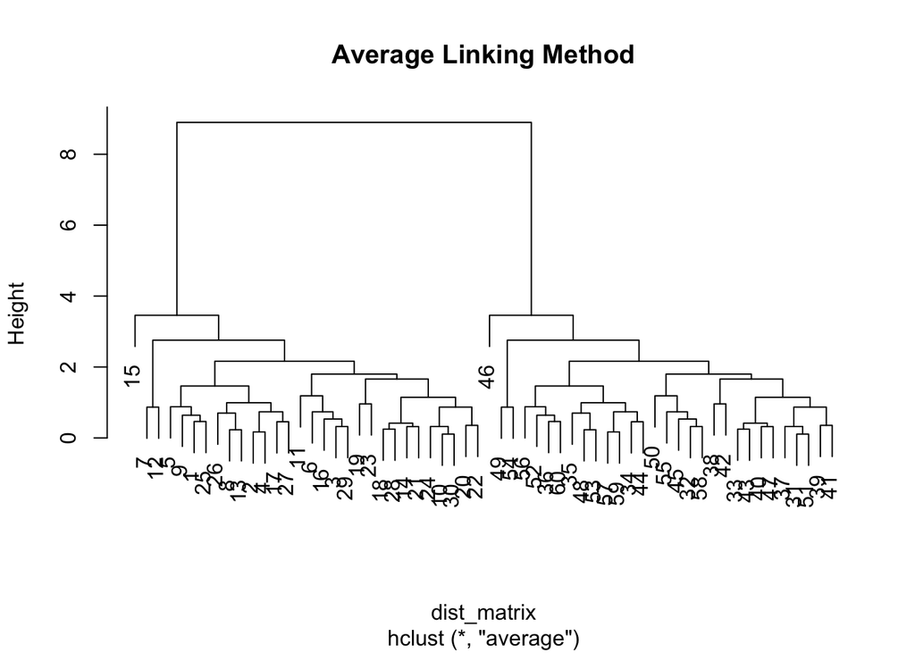

```r
hc.average <- hclust(dist_matrix, method = "average")
plot(hc.average, main = "Average Linking Method")
```

### What if our data are measured on different scales?

This is usually reality. We can normalize each data such that its mean = 0 and standard deviation = 1.

#### Step 1. Generate example data for clustering

```r
xc <- rbind(
 matrix(rnorm(100, mean=0, sd = 0.3), ncol = 2), # c1
 matrix(rnorm(100, mean = 1, sd = 0.3), ncol = 2), # c2
 matrix(c(rnorm(50, mean = 1, sd = 0.3), rnorm(50, mean = 0, sd = 0.3)), ncol = 2) # c3
)

colnames(xc) <- c("x", "y")
```

#### Step 2. Plot the data without clustering

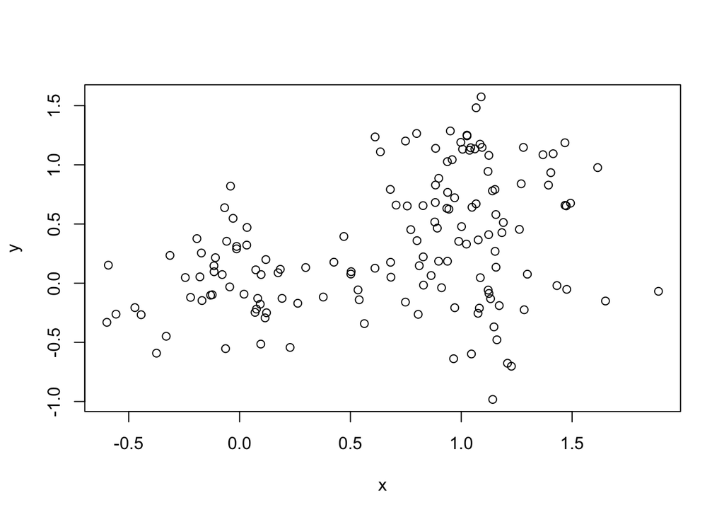

```r
plot(xc)
```

#### Step 3. Generate colors for known clusters

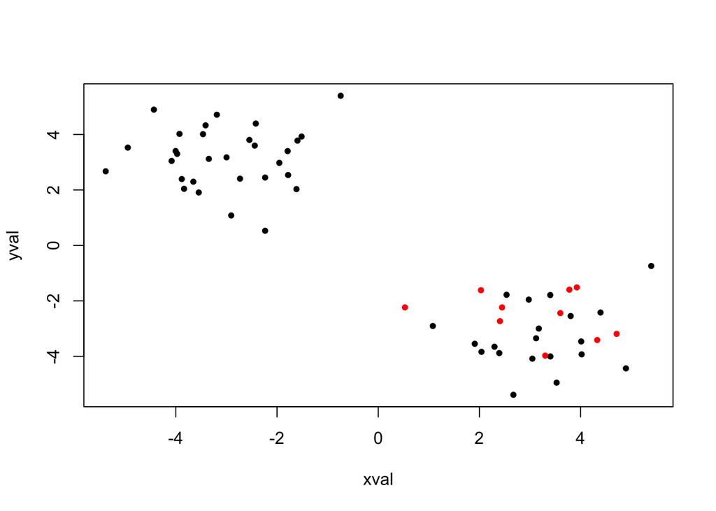

```r
# c1 c1 c1 c1 * 50 times ... c2 c2 c2 c2 ... c3 c3 c3 c3 ...
rep_colvec <- rep( c("c1", "c2", "c3"), each = 50)
reality_colvec <- as.factor(rep_colvec)
plot(example, col = reality_colvec, pch = 20)
```

Q. Use the `dist()`, `hclust()`, `plot()` and `cutree()` to return 2 to 3 clusters.

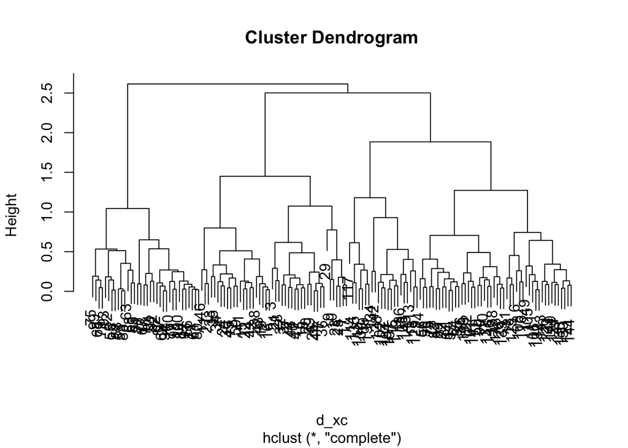

```r
# Create a distance matrix for the created vector xc
d_xc <- dist(xc)
hc_xc <- hclust(d_xc)
plot(hc_xc)
```

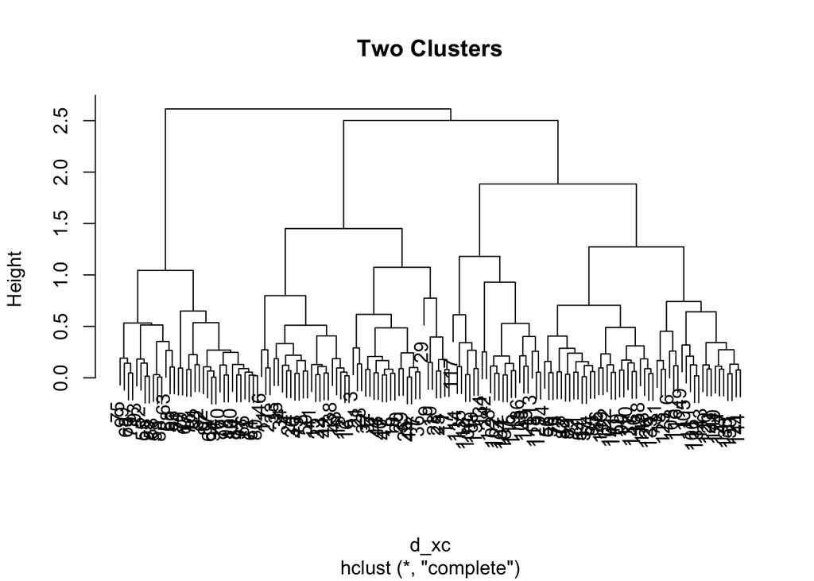

```r
grp2 <- cutree(hc_xc, k = 2)
plot(hc_xc, col = grp2, main = "Two Clusters", pch = 20)
```

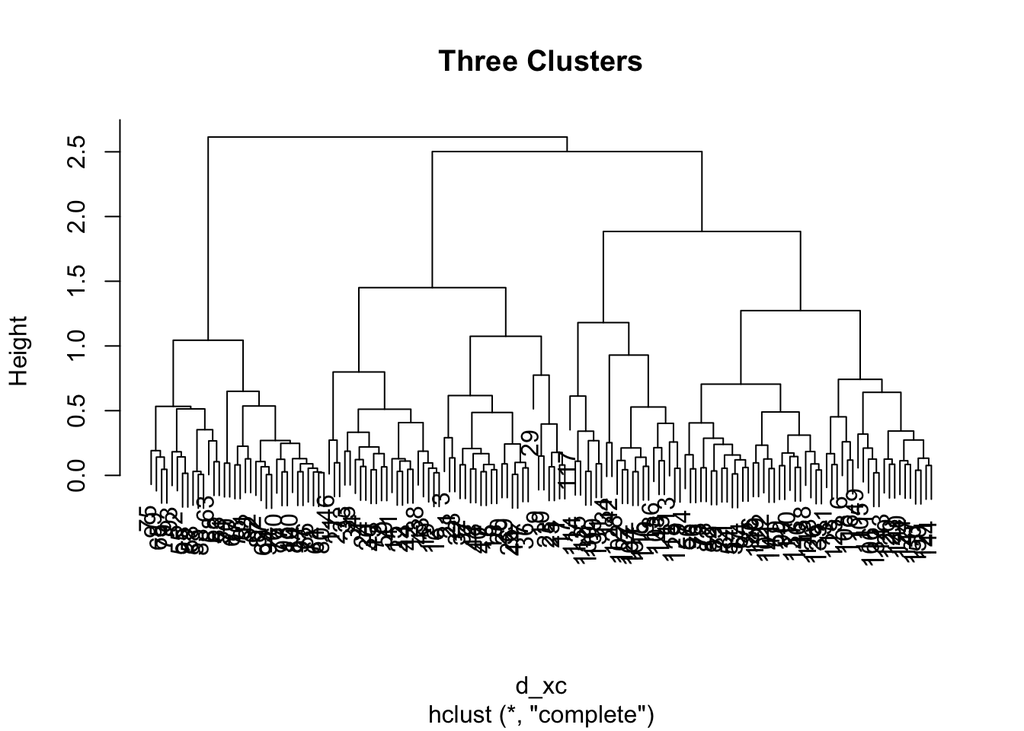

```r
grp3 <- cutree(hc_xc, k = 3)
plot(hc_xc, col = grp3, main = "Three Clusters", pch = 20)
```

```r
# Compare membership of the different groups obtained from hierarchical clustering
table(grp2)
```

```
## grp2
##   1   2
## 116  34
```

```r
table(grp3)
```

```
## grp3
##  1  2  3
## 46 70 34
```

## Principal component analysis

Let’s make an example dataset.

```r
# Initialize a blank 100 x 10 matrix
mydata <- matrix(nrow=100, ncol=10)

# Label the rows gene1, gene2, ... gene100
rownames(mydata) <- paste("gene", 1:100, sep="")

# Label the first five columns wt1, wt2, wt3, wt4, wt5 and the last five ko1, ko2, ko3, ko4, ko5
colnames(mydata) <- c( paste("wt", 1:5, sep=""), paste("ko", 1:5, sep="") )

# Fill in fake read counts with Poisson distribution
for(i in 1:nrow(mydata)) {
 wt.values <- rpois(5, lambda=sample(x=10:1000, size=1))
 ko.values <- rpois(5, lambda=sample(x=10:1000, size=1))
 mydata[i,] <- c(wt.values, ko.values)
}

# Let's check out our data!
head(mydata)
```

```
##       wt1 wt2 wt3 wt4 wt5 ko1 ko2 ko3 ko4 ko5
## gene1 467 468 481 505 455 573 594 573 590 631
## gene2 605 680 592 632 611 151 156 173 142 170
## gene3 730 715 742 762 707  99  92  89  94  83
## gene4 392 401 373 346 365 140 148 140 148 120
## gene5 453 408 452 483 457 810 728 734 815 767
## gene6 105 103  91  93  90 724 665 756 784 752
```

We see that the genes are in rows and the samples are in columns. The `prcomp()` function operates differently, so we need to transform our matrix such that the samples are in rows and the genes are in columns.

```r
trans_mydata <- t(mydata)
head(trans_mydata)
```

```
##     gene1 gene2 gene3 gene4 gene5 gene6 gene7 gene8 gene9 gene10 gene11
## wt1   467   605   730   392   453   105   284   691   311    441    157
## wt2   468   680   715   401   408   103   253   668   313    452    161
## wt3   481   592   742   373   452    91   214   655   325    529    168
## wt4   505   632   762   346   483    93   242   687   322    479    155
## wt5   455   611   707   365   457    90   250   701   307    485    139
## ko1   573   151    99   140   810   724   923   106   186    307    818
##     gene12 gene13 gene14 gene15 gene16 gene17 gene18 gene19 gene20 gene21
## wt1    140    569    510    777    386    496    587     14    119    502
## wt2    165    570    485    840    345    490    606     25    111    467
## wt3    148    592    500    795    370    509    541     20    108    513
## wt4    142    616    482    823    380    499    531     24    120    498
## wt5    146    630    479    812    392    511    538     24    108    475
## ko1    540    675    502    431    104    458    240    876    492     71
##     gene22 gene23 gene24 gene25 gene26 gene27 gene28 gene29 gene30 gene31
## wt1    650    951    282    789    708    395    124    138    589    228
## wt2    625    925    306    805    714    413    113    149    575    241
## wt3    660    912    276    825    728    389    106    165    595    251
## wt4    628    934    281    809    727    430    107    156    600    250
## wt5    664    927    281    776    736    407    108    148    643    240
## ko1    823    967    149    968    936    278    836    882    746    785
##     gene32 gene33 gene34 gene35 gene36 gene37 gene38 gene39 gene40 gene41
## wt1    851    165    824    701    718    233    738    772    250     95
## wt2    862    177    817    703    698    189    715    769    244     77
## wt3    781    164    810    746    648    233    722    817    242     78
## wt4    827    172    863    730    631    215    701    830    222    101
## wt5    852    153    830    733    675    199    721    786    253     91
## ko1    593    759    613    699    425    163    539    948    803    392
##     gene42 gene43 gene44 gene45 gene46 gene47 gene48 gene49 gene50 gene51
## wt1     98    781     78    521     71    587    838    811    584    880
## wt2     85    795     68    552     67    633    822    774    579    804
## wt3     91    788     82    535     54    559    870    845    541    837
## wt4     91    765     67    485     57    608    861    780    594    850
## wt5     84    833     78    535     57    616    848    795    600    846
## ko1    311    818    148    189    884     97    828    183    107    478
##     gene52 gene53 gene54 gene55 gene56 gene57 gene58 gene59 gene60 gene61
## wt1     74    355    613    630    891    760    960    979     71     42
## wt2     95    368    572    615    890    772    963    971     80     33
## wt3     91    345    559    667    867    784    954    947     84     41
## wt4     90    363    607    640    885    739    959    945     66     42
```

[output cut: 15 more lines]

```
## ko1    532    264    471    367    951    744    274    468     44    272
##     gene82 gene83 gene84 gene85 gene86 gene87 gene88 gene89 gene90 gene91
## wt1    194    508    494    840     96     42    627    228    318    274
## wt2    159    526    482    871     90     37    643    227    280    274
## wt3    206    493    517    819    104     42    596    220    263    268
## wt4    160    509    486    854    112     51    620    233    296    300
## wt5    182    531    479    802     92     29    650    219    292    280
## ko1    811    463    437    724    114     40    410    849     18    911
##     gene92 gene93 gene94 gene95 gene96 gene97 gene98 gene99 gene100
## wt1    636     28    429    792    775    650    485    911     864
## wt2    638     41    453    785    789    591    456    929     845
## wt3    685     17    466    806    727    639    467    923     836
## wt4    646     43    435    823    771    618    421    974     813
## wt5    666     33    430    808    795    648    454    949     853
## ko1    437    597    262    113    837    627    310    577     148
```

Now, we are ready for PCA!

```r
# In general, scaling is advisable such that all variables have unit variance
pca <- prcomp(trans_mydata, scale = TRUE)
# Since we have 10 samples, we have 10 PCs
attributes(pca)
```

```
## $names
## [1] "sdev"     "rotation" "center"   "scale"    "x"
##
## $class
## [1] "prcomp"
```

```r
pca$x
```

```
##           PC1        PC2         PC3        PC4         PC5         PC6
## wt1 -8.989657  0.1905887  0.06617250  0.9672306 -0.42069519  1.95148391
## wt2 -9.157160  0.4264496  2.19254644 -1.5201071 -0.51489109 -0.01881047
## wt3 -8.932598 -0.6137060 -2.32010227  1.5394687 -0.33718357 -0.67851558
## wt4 -8.652600 -2.0280364  0.18391996 -0.1164834 -0.84311513 -1.35140661
## wt5 -8.858037  2.0364245 -0.09059788 -0.8717677  2.07284883  0.03504201
## ko1  8.764924  2.0209348  1.09329645  2.3360768 -0.12378871  0.04719110
## ko2  9.164041  2.1295496 -1.38941280 -1.6144617 -1.87804393  0.10206211
## ko3  8.860270  0.5380338 -0.79946736 -0.2305529  1.24161999 -1.12560740
## ko4  8.467227 -2.8875830 -1.20335017 -0.8388348  0.74489558  1.31816229
## ko5  9.333590 -1.8126555  2.26699512  0.3494316  0.05835323 -0.27960136
##            PC7         PC8         PC9         PC10
## wt1 -1.1898292 -0.76167014  0.38847834 5.303917e-15
## wt2 -0.5275636  1.34540015 -0.06717957 4.203669e-15
## wt3 -0.1982979  0.62433293 -0.99595177 3.933485e-15
## wt4  0.8449139 -0.68413674  0.99548825 3.654629e-15
## wt5  1.0735617 -0.59788961 -0.34938184 3.317659e-15
## ko1  1.0473381  0.58396321  0.50738846 4.733193e-15
## ko2  0.2655774 -0.43301972 -0.26615392 5.457006e-15
## ko3 -1.8528598  0.04375409  0.63966725 3.107323e-15
## ko4  0.7946923  0.66583573  0.25493462 5.223686e-15
## ko5 -0.2575330 -0.78656990 -1.10728981 1.249868e-15
```

As you can tell, PC1 shows a lot of variance among the ten samples, whereas PC10 shows almost no variance.

Let’s make a PCA plot with PC1 and PC2!

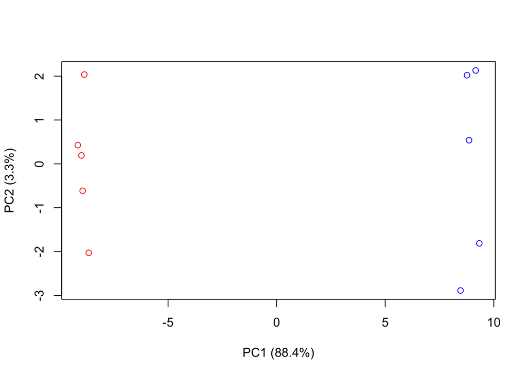

```
## integer(0)
```

```r
# First, calculate how much variance is captured per PC
pca_var <- pca$sdev ^ 2
# Convert into percent variance and round to first decimal place
per_var <- round( (pca_var / sum(pca_var) ) * 100, 1)
# Make color vector by searching for sample matches and converting sample names to colors
pca_colvec <- colnames(mydata)
pca_colvec[grep("wt", pca_colvec)] <- "red"
pca_colvec[grep("ko", pca_colvec)] <- "blue"
# Plot with colors and labels
plot( pca$x[,1], pca$x[,2],
      xlab = paste0("PC1 (", per_var[1], "%)"),
      ylab = paste0("PC2 (", per_var[2], "%)"),
      col = pca_colvec)
# Label some points and ESC when done
identify(pca$x[,1], pca$x[,2], labels = colnames(mydata))
```

This means that PC1 captured 88.4% of the variance in this dataset. We can also make a scree plot to see how much variance other PCs captured.

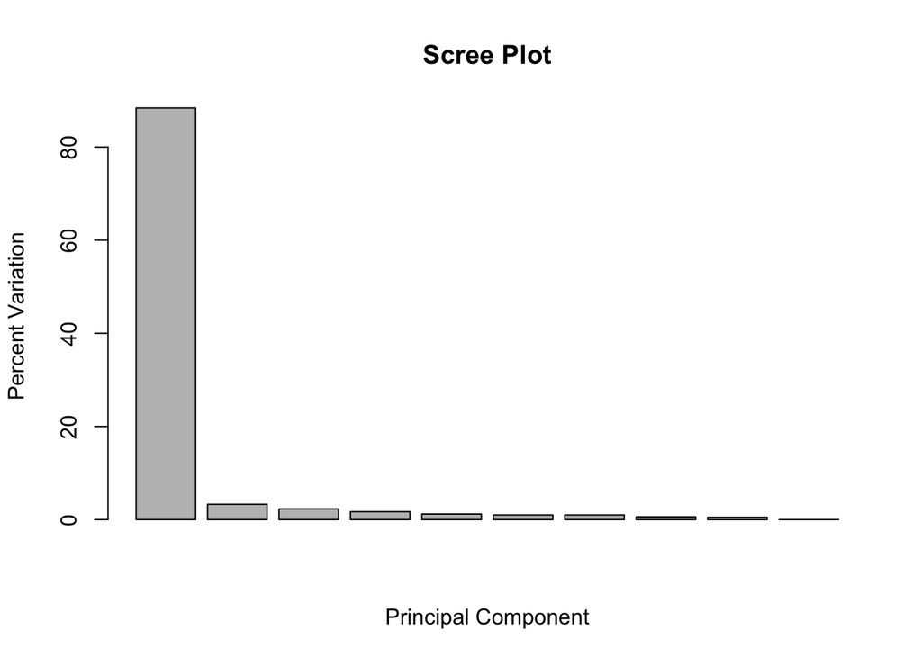

```r
barplot(per_var, main = "Scree Plot", xlab="Principal Component", ylab="Percent Variation")
```

We can also see which genes have the largest effect on PC1, the most important PC. In other words, what are the genes driving the split/structure seen in PC1?

```r
loading_scores <- pca$rotation[,1]
summary(loading_scores)
```

```
##     Min.  1st Qu.   Median     Mean  3rd Qu.     Max.
## -0.10625 -0.10551 -0.06892 -0.00818  0.10556  0.10631
```

```r
# Since we are interested in the magnitude of the contribution of each gene, take the absolute value
gene_scores <- abs(loading_scores)
# Now, sort the gene scores from high to low
gene_scores_ranked <- sort(gene_scores, decreasing = TRUE)
# Find the names of the top 5 genes
top_5_genes <- names(gene_scores_ranked[1:5])
top_5_genes
```

```
## [1] "gene29" "gene28" "gene46" "gene91" "gene58"
```

```r
# Show the score of each top 5 genes
pca$rotation[top_5_genes, 1]
```

```
##     gene29     gene28     gene46     gene91     gene58
##  0.1063089  0.1062940  0.1062905  0.1062587 -0.1062541
```

The way to interpret these gene scores is, the genes with the most positive loading scores are the ones that pushed the ko samples to the positive (right) side of the plot. Conversely, the genes with the most negative loading scores are the ones that pushed the wt samples to the negative (left) side of the plot.